# Optimal Treatment Analysis

## Outcome Variable

**Outcome Variable:** ever_wasted

## Predictor Variables

**Intervention Variable:** nhh

**Adjustment Set:**

- arm
- W_mage
- meducyrs
- feducyrs
- hhwealth_quart
- W_mhtcm
- W_mwtkg
- W_mbmi
- W_nrooms
- cleanck
- impfloor
- impsan
- safeh20
- delta_W_mage
- delta_meducyrs
- delta_feducyrs
- delta_hhwealth_quart
- delta_W_mhtcm
- delta_W_mwtkg
- delta_W_mbmi
- delta_W_nrooms
- delta_cleanck
- delta_impfloor
- delta_impsan
- delta_safeh20

## Stratifying Variables

The analysis was stratified on these variable(s):

- agecat
- studyid
- country

## Data Summary

| agecat | studyid | country | nhh | ever_wasted | n_cell | n |
| --- | --- | --- | --- | --- | --- | --- |
| 0-24 months | ki1000108-IRC | INDIA | 3 or less | 0 | 20 | 410 |
| 0-24 months | ki1000108-IRC | INDIA | 3 or less | 1 | 38 | 410 |
| 0-24 months | ki1000108-IRC | INDIA | 4-5 | 0 | 63 | 410 |
| 0-24 months | ki1000108-IRC | INDIA | 4-5 | 1 | 95 | 410 |
| 0-24 months | ki1000108-IRC | INDIA | 6-7 | 0 | 38 | 410 |
| 0-24 months | ki1000108-IRC | INDIA | 6-7 | 1 | 69 | 410 |
| 0-24 months | ki1000108-IRC | INDIA | 8+ | 0 | 20 | 410 |
| 0-24 months | ki1000108-IRC | INDIA | 8+ | 1 | 67 | 410 |
| 0-24 months | ki1000304b-SAS-FoodSuppl | INDIA | 3 or less | 0 | 4 | 106 |
| 0-24 months | ki1000304b-SAS-FoodSuppl | INDIA | 3 or less | 1 | 5 | 106 |
| 0-24 months | ki1000304b-SAS-FoodSuppl | INDIA | 4-5 | 0 | 19 | 106 |
| 0-24 months | ki1000304b-SAS-FoodSuppl | INDIA | 4-5 | 1 | 22 | 106 |
| 0-24 months | ki1000304b-SAS-FoodSuppl | INDIA | 6-7 | 0 | 20 | 106 |
| 0-24 months | ki1000304b-SAS-FoodSuppl | INDIA | 6-7 | 1 | 17 | 106 |
| 0-24 months | ki1000304b-SAS-FoodSuppl | INDIA | 8+ | 0 | 10 | 106 |
| 0-24 months | ki1000304b-SAS-FoodSuppl | INDIA | 8+ | 1 | 9 | 106 |
| 0-24 months | ki1017093-NIH-Birth | BANGLADESH | 3 or less | 0 | 58 | 624 |
| 0-24 months | ki1017093-NIH-Birth | BANGLADESH | 3 or less | 1 | 57 | 624 |
| 0-24 months | ki1017093-NIH-Birth | BANGLADESH | 4-5 | 0 | 134 | 624 |
| 0-24 months | ki1017093-NIH-Birth | BANGLADESH | 4-5 | 1 | 129 | 624 |
| 0-24 months | ki1017093-NIH-Birth | BANGLADESH | 6-7 | 0 | 72 | 624 |
| 0-24 months | ki1017093-NIH-Birth | BANGLADESH | 6-7 | 1 | 69 | 624 |
| 0-24 months | ki1017093-NIH-Birth | BANGLADESH | 8+ | 0 | 62 | 624 |
| 0-24 months | ki1017093-NIH-Birth | BANGLADESH | 8+ | 1 | 43 | 624 |
| 0-24 months | ki1017093b-PROVIDE | BANGLADESH | 3 or less | 0 | 98 | 700 |
| 0-24 months | ki1017093b-PROVIDE | BANGLADESH | 3 or less | 1 | 42 | 700 |
| 0-24 months | ki1017093b-PROVIDE | BANGLADESH | 4-5 | 0 | 211 | 700 |
| 0-24 months | ki1017093b-PROVIDE | BANGLADESH | 4-5 | 1 | 111 | 700 |
| 0-24 months | ki1017093b-PROVIDE | BANGLADESH | 6-7 | 0 | 94 | 700 |
| 0-24 months | ki1017093b-PROVIDE | BANGLADESH | 6-7 | 1 | 57 | 700 |

[output cut: 114 more lines]

The following strata were considered:

- agecat: 0-24 months, studyid: ki1000108-IRC, country: INDIA
- agecat: 0-24 months, studyid: ki1000304b-SAS-FoodSuppl, country: INDIA
- agecat: 0-24 months, studyid: ki1017093-NIH-Birth, country: BANGLADESH
- agecat: 0-24 months, studyid: ki1017093b-PROVIDE, country: BANGLADESH
- agecat: 0-24 months, studyid: ki1017093c-NIH-Crypto, country: BANGLADESH
- agecat: 0-24 months, studyid: ki1148112-LCNI-5, country: MALAWI
- agecat: 0-6 months, studyid: ki1000108-IRC, country: INDIA
- agecat: 0-6 months, studyid: ki1000304b-SAS-FoodSuppl, country: INDIA
- agecat: 0-6 months, studyid: ki1017093-NIH-Birth, country: BANGLADESH
- agecat: 0-6 months, studyid: ki1017093b-PROVIDE, country: BANGLADESH
- agecat: 0-6 months, studyid: ki1017093c-NIH-Crypto, country: BANGLADESH
- agecat: 0-6 months, studyid: ki1148112-LCNI-5, country: MALAWI
- agecat: 6-24 months, studyid: ki1000108-IRC, country: INDIA
- agecat: 6-24 months, studyid: ki1000304b-SAS-FoodSuppl, country: INDIA
- agecat: 6-24 months, studyid: ki1017093-NIH-Birth, country: BANGLADESH
- agecat: 6-24 months, studyid: ki1017093b-PROVIDE, country: BANGLADESH
- agecat: 6-24 months, studyid: ki1017093c-NIH-Crypto, country: BANGLADESH
- agecat: 6-24 months, studyid: ki1148112-LCNI-5, country: MALAWI

### Dropped Strata

Some strata were dropped due to rare outcomes:

- agecat: 0-24 months, studyid: ki1000304b-SAS-FoodSuppl, country: INDIA
- agecat: 0-6 months, studyid: ki1000304b-SAS-FoodSuppl, country: INDIA
- agecat: 0-6 months, studyid: ki1148112-LCNI-5, country: MALAWI
- agecat: 6-24 months, studyid: ki1000304b-SAS-FoodSuppl, country: INDIA

## Methods Detail

We’re interested in the causal parameters $E[Y_a]$ for all values of $a \in \mathcal{A}$. These parameters represent the mean outcome if, possibly contrary to fact, we intervened to set all units to have $A=a$. Under the randomization and positivity assumptions, these are identified by the statistical parameters $\psi_a=E_W[E_{Y|A,W}(Y|A=a,W)]$. In addition, we’re interested in the mean of $Y$, $E[Y]$ under no intervention (the observed mean). We will estimate these parameters by using SuperLearner to fit the relevant likelihood factors – $E_{Y|A,W}(Y|A=a,W)$ and $p(A=a|W)$, and then updating our likelihood fit using a joint TMLE.

For unadjusted analyses ($W=\{\}$), initial likelihoods were estimated using Lrnr_glm to estimate the simple $E(Y|A)$ and Lrnr_mean to estimate $p(A)$. For adjusted analyses, a small library containing Lrnr_glmnet, Lrnr_xgboost, and Lrnr_mean was used.

Having estimated these parameters, we will then use the delta method to estimate relative risks and attributable risks relative to a prespecified baseline level of $A$.

# Results Detail

## Results Plots

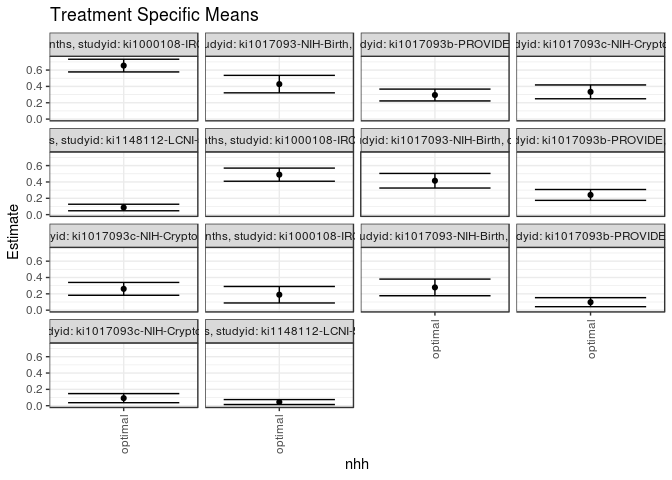

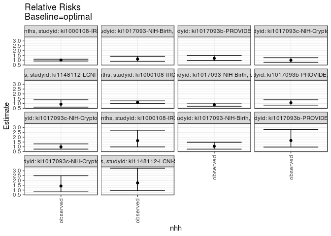

## Results Table

### Parameter: TSM

| agecat | studyid | country | intervention_level | baseline_level | estimate | ci_lower | ci_upper |
| --- | --- | --- | --- | --- | --- | --- | --- |
| 0-24 months | ki1000108-IRC | INDIA | optimal | NA | 0.6548856 | 0.5772439 | 0.7325274 |
| 0-24 months | ki1017093-NIH-Birth | BANGLADESH | optimal | NA | 0.4280328 | 0.3211836 | 0.5348820 |
| 0-24 months | ki1017093b-PROVIDE | BANGLADESH | optimal | NA | 0.2947410 | 0.2223522 | 0.3671298 |
| 0-24 months | ki1017093c-NIH-Crypto | BANGLADESH | optimal | NA | 0.3334247 | 0.2487536 | 0.4180958 |
| 0-24 months | ki1148112-LCNI-5 | MALAWI | optimal | NA | 0.0870930 | 0.0471810 | 0.1270050 |
| 0-6 months | ki1000108-IRC | INDIA | optimal | NA | 0.4892908 | 0.4089579 | 0.5696237 |
| 0-6 months | ki1017093-NIH-Birth | BANGLADESH | optimal | NA | 0.4150463 | 0.3256909 | 0.5044017 |
| 0-6 months | ki1017093b-PROVIDE | BANGLADESH | optimal | NA | 0.2411411 | 0.1746336 | 0.3076487 |
| 0-6 months | ki1017093c-NIH-Crypto | BANGLADESH | optimal | NA | 0.2609714 | 0.1823606 | 0.3395821 |
| 6-24 months | ki1000108-IRC | INDIA | optimal | NA | 0.1890997 | 0.0879672 | 0.2902323 |
| 6-24 months | ki1017093-NIH-Birth | BANGLADESH | optimal | NA | 0.2785456 | 0.1767250 | 0.3803661 |
| 6-24 months | ki1017093b-PROVIDE | BANGLADESH | optimal | NA | 0.0976132 | 0.0422813 | 0.1529452 |
| 6-24 months | ki1017093c-NIH-Crypto | BANGLADESH | optimal | NA | 0.0926507 | 0.0369790 | 0.1483224 |
| 6-24 months | ki1148112-LCNI-5 | MALAWI | optimal | NA | 0.0448962 | 0.0144645 | 0.0753279 |

### Parameter: E(Y)

| agecat | studyid | country | intervention_level | baseline_level | estimate | ci_lower | ci_upper |
| --- | --- | --- | --- | --- | --- | --- | --- |
| 0-24 months | ki1000108-IRC | INDIA | observed | NA | 0.6560976 | 0.6100625 | 0.7021326 |
| 0-24 months | ki1017093-NIH-Birth | BANGLADESH | observed | NA | 0.4775641 | 0.4383415 | 0.5167867 |
| 0-24 months | ki1017093b-PROVIDE | BANGLADESH | observed | NA | 0.3514286 | 0.3160364 | 0.3868207 |
| 0-24 months | ki1017093c-NIH-Crypto | BANGLADESH | observed | NA | 0.3311346 | 0.2976093 | 0.3646598 |
| 0-24 months | ki1148112-LCNI-5 | MALAWI | observed | NA | 0.0807834 | 0.0620863 | 0.0994804 |
| 0-6 months | ki1000108-IRC | INDIA | observed | NA | 0.5439024 | 0.4956326 | 0.5921723 |
| 0-6 months | ki1017093-NIH-Birth | BANGLADESH | observed | NA | 0.3569132 | 0.3192325 | 0.3945938 |
| 0-6 months | ki1017093b-PROVIDE | BANGLADESH | observed | NA | 0.2585714 | 0.2261125 | 0.2910304 |
| 0-6 months | ki1017093c-NIH-Crypto | BANGLADESH | observed | NA | 0.2585752 | 0.2273844 | 0.2897660 |
| 6-24 months | ki1000108-IRC | INDIA | observed | NA | 0.3097561 | 0.2649438 | 0.3545684 |
| 6-24 months | ki1017093-NIH-Birth | BANGLADESH | observed | NA | 0.2939002 | 0.2554778 | 0.3323226 |
| 6-24 months | ki1017093b-PROVIDE | BANGLADESH | observed | NA | 0.1609756 | 0.1319065 | 0.1900447 |
| 6-24 months | ki1017093c-NIH-Crypto | BANGLADESH | observed | NA | 0.1315069 | 0.1069744 | 0.1560393 |
| 6-24 months | ki1148112-LCNI-5 | MALAWI | observed | NA | 0.0782609 | 0.0596958 | 0.0968259 |

### Parameter: RR

| agecat | studyid | country | intervention_level | baseline_level | estimate | ci_lower | ci_upper |
| --- | --- | --- | --- | --- | --- | --- | --- |
| 0-24 months | ki1000108-IRC | INDIA | observed | optimal | 1.0018506 | 0.9111239 | 1.101611 |
| 0-24 months | ki1017093-NIH-Birth | BANGLADESH | observed | optimal | 1.1157185 | 0.8861211 | 1.404805 |
| 0-24 months | ki1017093b-PROVIDE | BANGLADESH | observed | optimal | 1.1923302 | 0.9528363 | 1.492021 |
| 0-24 months | ki1017093c-NIH-Crypto | BANGLADESH | observed | optimal | 0.9931316 | 0.7863734 | 1.254252 |
| 0-24 months | ki1148112-LCNI-5 | MALAWI | observed | optimal | 0.9275528 | 0.6240589 | 1.378643 |
| 0-6 months | ki1000108-IRC | INDIA | observed | optimal | 1.1116138 | 0.9759167 | 1.266179 |
| 0-6 months | ki1017093-NIH-Birth | BANGLADESH | observed | optimal | 0.8599358 | 0.7140133 | 1.035681 |
| 0-6 months | ki1017093b-PROVIDE | BANGLADESH | observed | optimal | 1.0722825 | 0.8326896 | 1.380814 |
| 0-6 months | ki1017093c-NIH-Crypto | BANGLADESH | observed | optimal | 0.9908183 | 0.7552659 | 1.299835 |
| 6-24 months | ki1000108-IRC | INDIA | observed | optimal | 1.6380568 | 0.9855066 | 2.722691 |
| 6-24 months | ki1017093-NIH-Birth | BANGLADESH | observed | optimal | 1.0551242 | 0.7543688 | 1.475786 |
| 6-24 months | ki1017093b-PROVIDE | BANGLADESH | observed | optimal | 1.6491166 | 0.9689938 | 2.806608 |
| 6-24 months | ki1017093c-NIH-Crypto | BANGLADESH | observed | optimal | 1.4193830 | 0.8093173 | 2.489318 |
| 6-24 months | ki1148112-LCNI-5 | MALAWI | observed | optimal | 1.7431518 | 0.9267807 | 3.278638 |

### Parameter: PAR

| agecat | studyid | country | intervention_level | baseline_level | estimate | ci_lower | ci_upper |
| --- | --- | --- | --- | --- | --- | --- | --- |
| 0-24 months | ki1000108-IRC | INDIA | optimal | NA | 0.0012119 | -0.0609525 | 0.0633764 |
| 0-24 months | ki1017093-NIH-Birth | BANGLADESH | optimal | NA | 0.0495313 | -0.0489042 | 0.1479668 |
| 0-24 months | ki1017093b-PROVIDE | BANGLADESH | optimal | NA | 0.0566876 | -0.0096582 | 0.1230334 |
| 0-24 months | ki1017093c-NIH-Crypto | BANGLADESH | optimal | NA | -0.0022901 | -0.0801210 | 0.0755408 |
| 0-24 months | ki1148112-LCNI-5 | MALAWI | optimal | NA | -0.0063096 | -0.0408510 | 0.0282317 |
| 0-6 months | ki1000108-IRC | INDIA | optimal | NA | 0.0546116 | -0.0088267 | 0.1180499 |
| 0-6 months | ki1017093-NIH-Birth | BANGLADESH | optimal | NA | -0.0581331 | -0.1356544 | 0.0193882 |
| 0-6 months | ki1017093b-PROVIDE | BANGLADESH | optimal | NA | 0.0174303 | -0.0437149 | 0.0785755 |
| 0-6 months | ki1017093c-NIH-Crypto | BANGLADESH | optimal | NA | -0.0023962 | -0.0732514 | 0.0684591 |
| 6-24 months | ki1000108-IRC | INDIA | optimal | NA | 0.1206564 | 0.0238116 | 0.2175011 |
| 6-24 months | ki1017093-NIH-Birth | BANGLADESH | optimal | NA | 0.0153546 | -0.0780376 | 0.1087468 |
| 6-24 months | ki1017093b-PROVIDE | BANGLADESH | optimal | NA | 0.0633624 | 0.0105598 | 0.1161650 |
| 6-24 months | ki1017093c-NIH-Crypto | BANGLADESH | optimal | NA | 0.0388561 | -0.0133301 | 0.0910423 |
| 6-24 months | ki1148112-LCNI-5 | MALAWI | optimal | NA | 0.0333647 | 0.0040227 | 0.0627067 |

### Parameter: PAF

| agecat | studyid | country | intervention_level | baseline_level | estimate | ci_lower | ci_upper |
| --- | --- | --- | --- | --- | --- | --- | --- |
| 0-24 months | ki1000108-IRC | INDIA | optimal | NA | 0.0018472 | -0.0975455 | 0.0922390 |
| 0-24 months | ki1017093-NIH-Birth | BANGLADESH | optimal | NA | 0.1037166 | -0.1285139 | 0.2881577 |
| 0-24 months | ki1017093b-PROVIDE | BANGLADESH | optimal | NA | 0.1613062 | -0.0494982 | 0.3297680 |
| 0-24 months | ki1017093c-NIH-Crypto | BANGLADESH | optimal | NA | -0.0069159 | -0.2716605 | 0.2027119 |
| 0-24 months | ki1148112-LCNI-5 | MALAWI | optimal | NA | -0.0781057 | -0.6024129 | 0.2746489 |
| 0-6 months | ki1000108-IRC | INDIA | optimal | NA | 0.1004070 | -0.0246776 | 0.2102223 |
| 0-6 months | ki1017093-NIH-Birth | BANGLADESH | optimal | NA | -0.1628775 | -0.4005342 | 0.0344512 |
| 0-6 months | ki1017093b-PROVIDE | BANGLADESH | optimal | NA | 0.0674099 | -0.2009277 | 0.2757897 |
| 0-6 months | ki1017093c-NIH-Crypto | BANGLADESH | optimal | NA | -0.0092668 | -0.3240369 | 0.2306715 |
| 6-24 months | ki1000108-IRC | INDIA | optimal | NA | 0.3895206 | -0.0147066 | 0.6327163 |
| 6-24 months | ki1017093-NIH-Birth | BANGLADESH | optimal | NA | 0.0522443 | -0.3256116 | 0.3223951 |
| 6-24 months | ki1017093b-PROVIDE | BANGLADESH | optimal | NA | 0.3936147 | -0.0319984 | 0.6436980 |
| 6-24 months | ki1017093c-NIH-Crypto | BANGLADESH | optimal | NA | 0.2954685 | -0.2356094 | 0.5982836 |
| 6-24 months | ki1148112-LCNI-5 | MALAWI | optimal | NA | 0.4263265 | -0.0790039 | 0.6949953 |